# Assignment 2

Maninderpreet Singh Puri

21/10/2020

Task 1 of 2: Correlation

1). Missing Values:

Importing Libraries

```r
library(tidyr)
library(dplyr)
library(datasets)
library(tidyverse)
library(ggpubr)
```

Reading Data

```r
mdata = read.csv("Movie.csv")#load data
glimpse(mdata)#data has 26 columns and 3891 rows
```

```
## Rows: 3,891
## Columns: 26
## $ Color                     <chr> "Color", "Color", "Color", "Color", "Colo...
## $ Director                  <chr> "James Cameron", "Gore Verbinski", "Sam M...
## $ Reviews                   <int> 723, 302, 602, 813, 462, 392, 324, 635, 3...
## $ Duration                  <int> 178, 169, 148, 164, 132, 156, 100, 141, 1...
## $ Director_facebook_likes   <int> 0, 563, 0, 22000, 475, 0, 15, 0, 282, 0, ...
## $ Actor_3_facebook_likes    <int> 855, 1000, 161, 23000, 530, 4000, 284, 19...
## $ Actor_2_name              <chr> "Joel David Moore", "Orlando Bloom", "Ror...
## $ Actor_1_facebook_likes    <int> 1000, 40000, 11000, 27000, 640, 24000, 79...
## $ Gross                     <int> 760505847, 309404152, 200074175, 44813064...
## $ Genre                     <chr> "Action", "Action", "Action", "Action", "...
## $ Actor_1_name              <chr> "CCH Pounder", "Johnny Depp", "Christoph ...
## $ Title                     <chr> "Avatara", "Pirates of the Caribbean: At ...
## $ Votes                     <int> 886204, 471220, 275868, 1144337, 212204, ...
## $ Cast_total_facebook_likes <int> 2791, 46563, 11554, 95000, 2277, 39000, 1...
## $ Actor_3_name              <chr> "Wes Studi", "Jack Davenport", "Stephanie...
## $ Facenumber_in_poster      <int> 0, 0, 1, 0, 1, 0, 1, 4, 3, 0, 0, 1, 2, 1,...
## $ Plot_keywords             <chr> "avatar|future|marine|native|paraplegic",...
## $ Movie_imdb_link           <chr> "http://www.imdb.com/title/tt0499549/?ref...
## $ Language                  <chr> "English", "English", "English", "English...
## $ Content_rating            <chr> "PG-13", "", "PG-13", "PG-13", "PG-13", "...
## $ Budget                    <dbl> 237000000, 300000000, 245000000, 25000000...
## $ Year                      <int> 2009, 2007, 2015, 2012, 2012, 2007, 2010,...
## $ Actor_2_facebook_likes    <int> 936, 5000, 393, 23000, 632, 11000, 553, 2...
## $ Imdb_score                <dbl> 7.9, 7.1, 6.8, 8.5, 6.6, 6.2, 7.8, 7.5, 7...
## $ Aspect_ratio              <dbl> 1.78, 2.35, 2.35, 2.35, 2.35, 2.35, 1.85,...
## $ Movie_facebook_likes      <int> 33000, 0, 85000, 164000, 24000, 0, 29000,...
```

I am selecting the variables of interest and dropping variables that are not of interest(attributes about structure). This will process the variables which are important for movie evaluation.

```r
mdata = mdata[,c(3,5,9,13,14,21,24,26)]
```

Identifying NA values in remaining columns

```r
missing_Reviews <- sum(is.na(mdata$Reviews))
missing_Reviews# 1 NA values
```

```
## [1] 1
```

```r
missing_Director_facebook_likes <- sum(is.na(mdata$Director_facebook_likes))
missing_Director_facebook_likes# 0 NA values
```

```
## [1] 0
```

```r
missing_Gross <- sum(is.na(mdata$Gross))
missing_Gross# 0 NA values
```

```
## [1] 0
```

```r
missing_Votes <- sum(is.na(mdata$Votes))
missing_Votes# 0 NA values
```

```
## [1] 0
```

```r
missing_Cast_total_facebook_likes <- sum(is.na(mdata$Cast_total_facebook_likes))
missing_Cast_total_facebook_likes# 0 NA values
```

```
## [1] 0
```

```r
missing_Content_rating <- sum(is.na(mdata$Content_rating))
missing_Content_rating# 0 NA values
```

```
## [1] 0
```

```r
missing_Budget <- sum(is.na(mdata$Budget))
missing_Budget# 0 NA values
```

```
## [1] 0
```

```r
missing_Imdb_score <- sum(is.na(mdata$Imdb_score))
missing_Imdb_score# 0 NA values
```

```
## [1] 0
```

```r
missing_Movie_facebook_likes <- sum(is.na(mdata$Movie_facebook_likes))
missing_Movie_facebook_likes# 0 NA values
```

```
## [1] 0
```

As the number of missing values is just 1, so we can drop that row.

```r
mdata <- na.omit(mdata)
```

2. Exploration:

Adding Profit column

```r
Profit <- mdata$Gross - mdata$Budget
mdata$Profit= Profit
```

Normalizing data in all variables

```r
mdata$Reviews <-(mdata$Reviews - min(mdata$Reviews)) /(max(mdata$Reviews)-min(mdata$Reviews))

mdata$Director_facebook_likes <-(mdata$Director_facebook_likes - min(mdata$Director_facebook_likes))/(max(mdata$Director_facebook_likes)-min(mdata$Director_facebook_likes))

mdata$Gross <-(mdata$Gross - min(mdata$Gross)) /(max(mdata$Gross)-min(mdata$Gross))

mdata$Votes <-(mdata$Votes - min(mdata$Votes)) /(max(mdata$Votes)-min(mdata$Votes))

mdata$Cast_total_facebook_likes <-(mdata$Cast_total_facebook_likes - min(mdata$Cast_total_facebook_likes)) /(max(mdata$Cast_total_facebook_likes)-min(mdata$Cast_total_facebook_likes))

mdata$Budget <-(mdata$Budget - min(mdata$Budget)) /(max(mdata$Budget)-min(mdata$Budget))

mdata$Imdb_score <-(mdata$Imdb_score - min(mdata$Imdb_score)) /(max(mdata$Imdb_score)-min(mdata$Imdb_score))

mdata$Movie_facebook_likes <-(mdata$Movie_facebook_likes - min(mdata$Movie_facebook_likes)) /(max(mdata$Movie_facebook_likes)-min(mdata$Movie_facebook_likes))

mdata$Profit <-(mdata$Profit - min(mdata$Profit)) /(max(mdata$Profit)-min(mdata$Profit))
```

Relationship between Profit and other variables. The trend line shows the relationship is positive, negative or there is no relation.

```r
ggscatter(mdata, x = "Reviews", y = "Profit", fill = "lightgray", shape = 4,
size = 2, color = "#00AFBB", add = c("reg.line"))
```

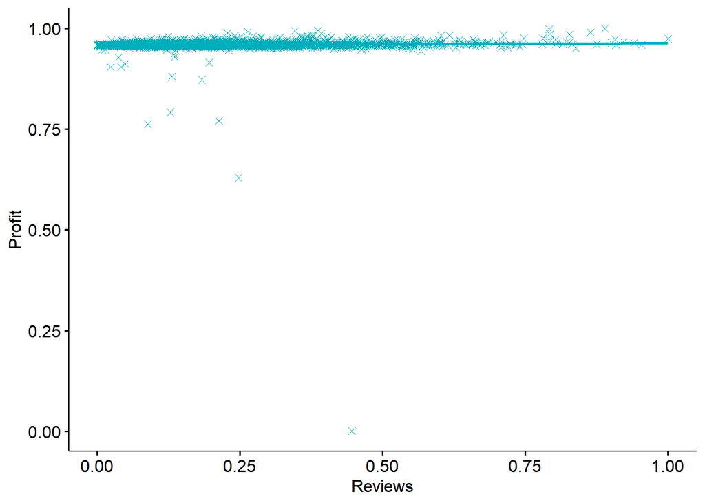

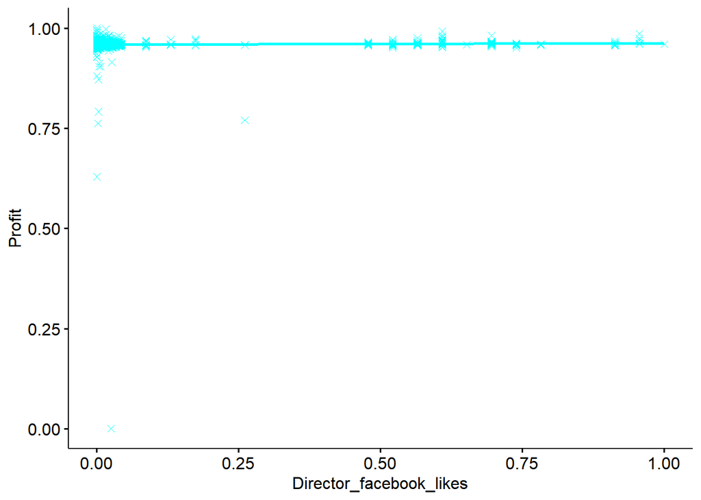

```r
ggscatter(mdata, x = "Director_facebook_likes", y = "Profit", fill = "lightgray", shape = 4, size = 2, color = "Cyan", add = c("reg.line"))
```

```r
ggscatter(mdata, x = "Gross", y = "Profit", fill = "lightgray", shape = 4,
size = 2, color = "#E7B800", add = c("reg.line"))
```

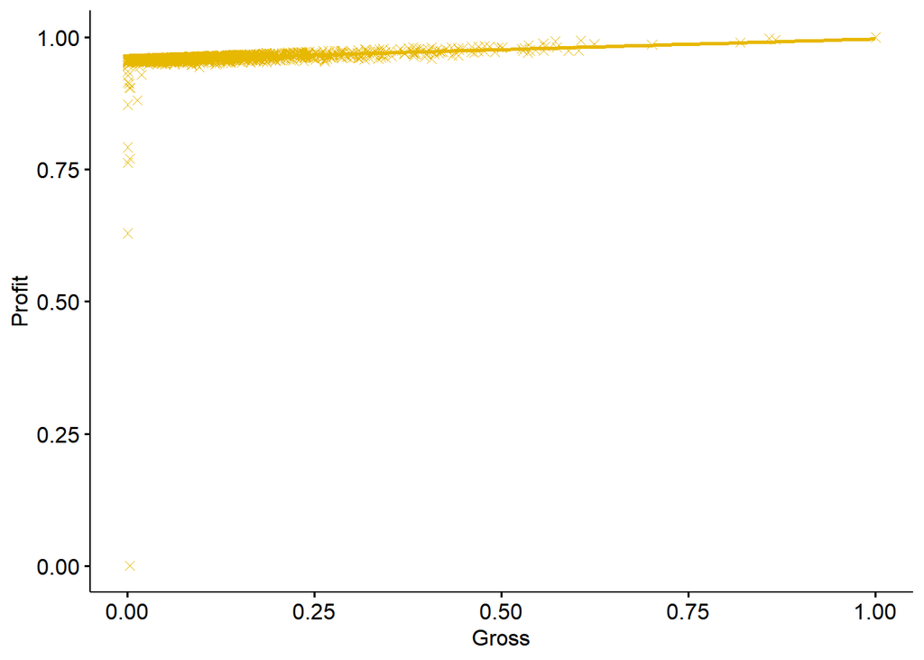

```r
ggscatter(mdata, x = "Votes", y = "Profit", fill = "lightgray", shape = 4,
size = 2, color = "#FC4E07", add = c("reg.line"))
```

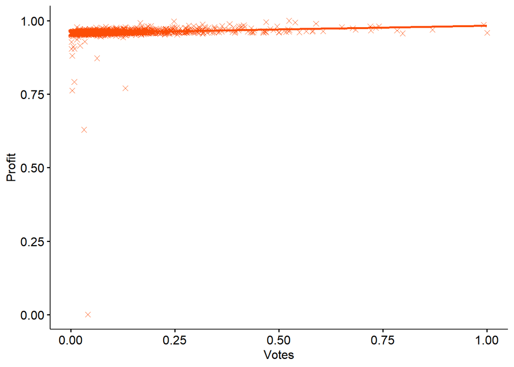

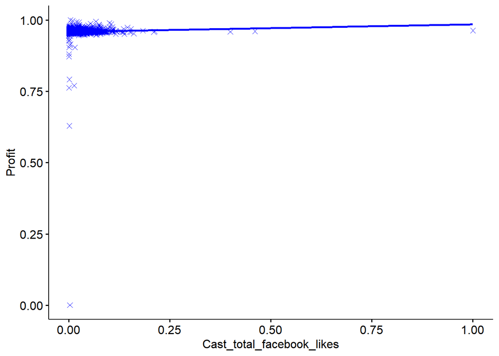

```r
ggscatter(mdata, x = "Cast_total_facebook_likes", y = "Profit", fill = "lightgray", shape = 4, size = 2, color = "Blue", add = c("reg.line"))
```

```r
ggscatter(mdata, x = "Budget", y = "Profit", fill = "lightgray", shape = 4,
size = 2, color = "Red", add = c("reg.line"))
```

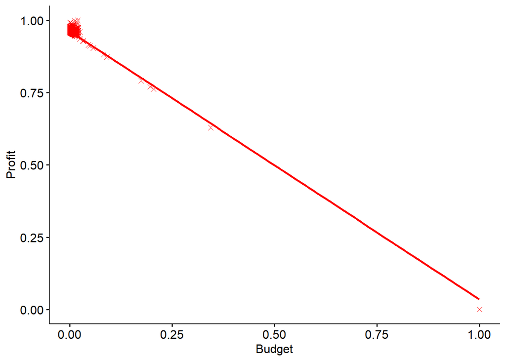

```r
ggscatter(mdata, x = "Imdb_score", y = "Profit", fill = "lightgray", shape = 4,
size = 2, color = "Green", add = c("reg.line"))
```

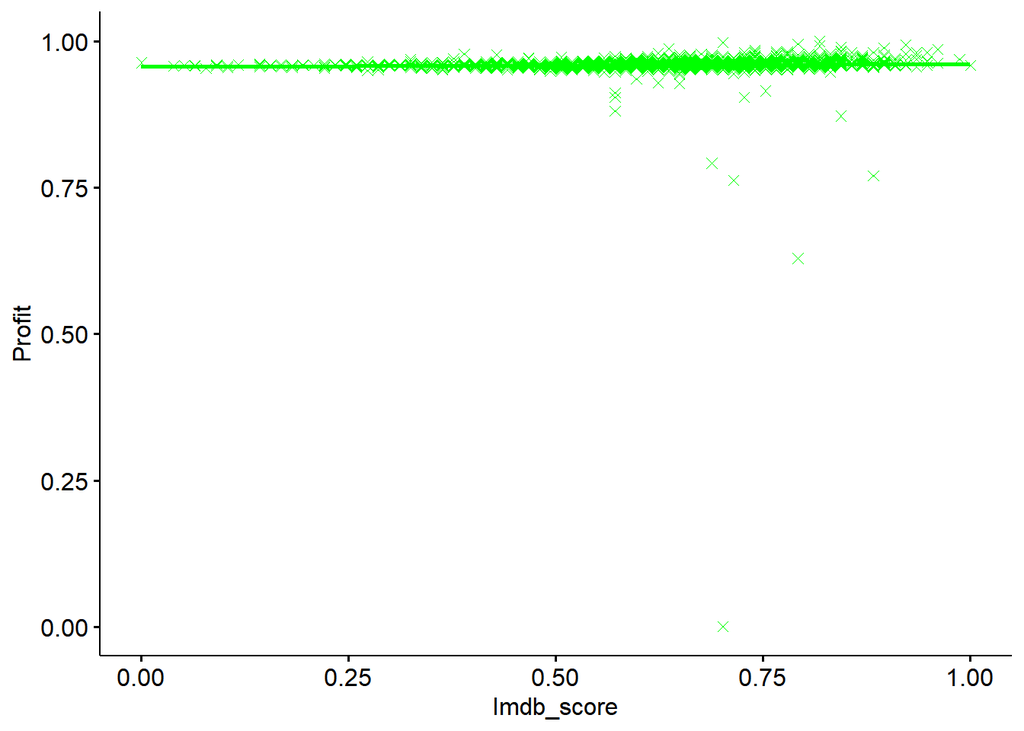

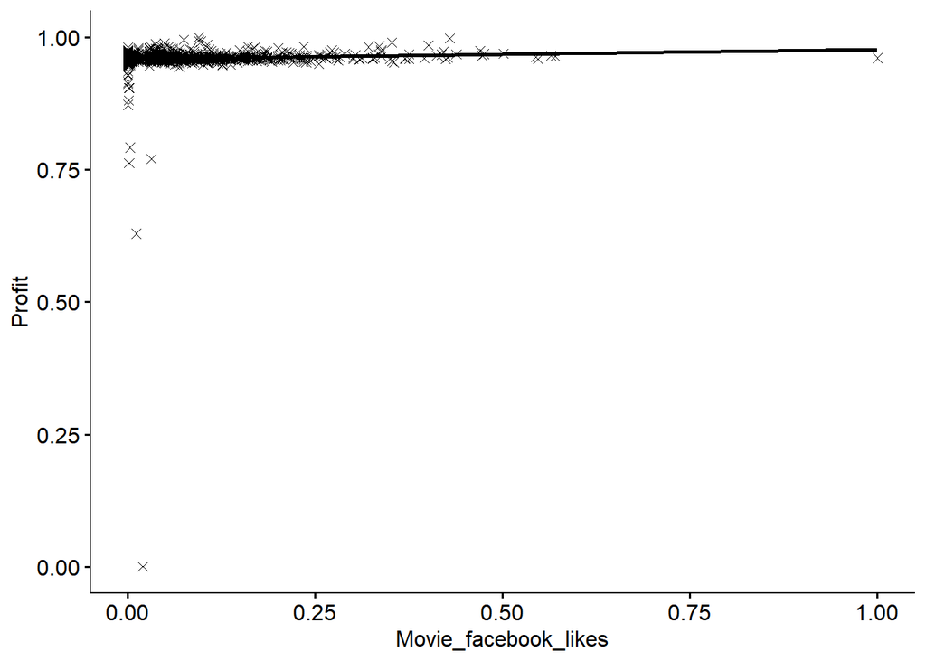

```r
ggscatter(mdata, x = "Movie_facebook_likes", y = "Profit", fill = "lightgray", shape = 4, size = 2, color = "Black", add = c("reg.line"))
```

Calculating correlation between the variable(s) used in the Data set.

```r
res4 <- cor(mdata, use = "everything", method = c("kendall"))
round(res4, 2)
```

```
##                           Reviews Director_facebook_likes Gross Votes
## Reviews                      1.00                    0.14  0.32  0.58
## Director_facebook_likes      0.14                    1.00  0.12  0.17
## Gross                        0.32                    0.12  1.00  0.51
## Votes                        0.58                    0.17  0.51  1.00
## Cast_total_facebook_likes    0.23                    0.16  0.25  0.30
## Budget                       0.27                    0.12  0.46  0.34
## Imdb_score                   0.23                    0.09  0.08  0.32
## Movie_facebook_likes         0.27                    0.04  0.09  0.19
## Profit                       0.11                    0.04  0.44  0.26
##                           Cast_total_facebook_likes Budget Imdb_score
## Reviews                                        0.23   0.27       0.23
## Director_facebook_likes                        0.16   0.12       0.09
## Gross                                          0.25   0.46       0.08
## Votes                                          0.30   0.34       0.32
## Cast_total_facebook_likes                      1.00   0.27       0.08
## Budget                                         0.27   1.00      -0.05
## Imdb_score                                     0.08  -0.05       1.00
## Movie_facebook_likes                           0.11   0.08       0.12
## Profit                                         0.06  -0.10       0.16
##                           Movie_facebook_likes Profit
## Reviews                                   0.27   0.11
## Director_facebook_likes                   0.04   0.04
## Gross                                     0.09   0.44
## Votes                                     0.19   0.26
## Cast_total_facebook_likes                 0.11   0.06
## Budget                                    0.08  -0.10
## Imdb_score                                0.12   0.16
## Movie_facebook_likes                      1.00   0.04
## Profit                                    0.04   1.00
```

Listing and plotting Strong and Weak Correlations

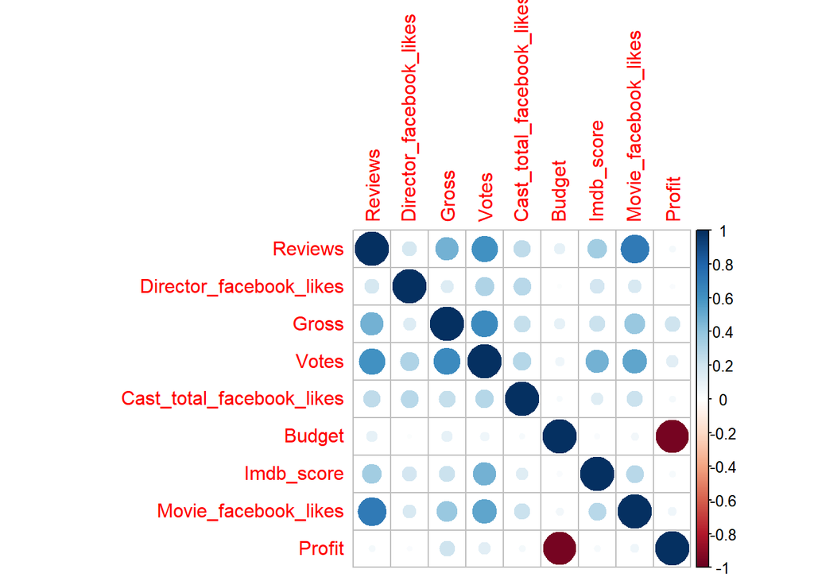

```r
library(corrplot)
cr = cor(mdata)
corrplot(cr)
```

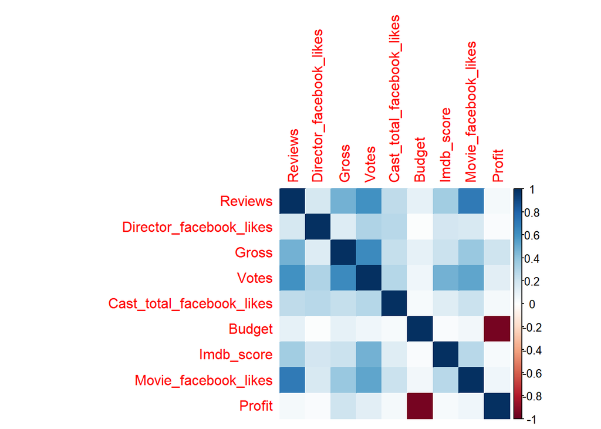

```r
corrplot(cr, method = "color")
```

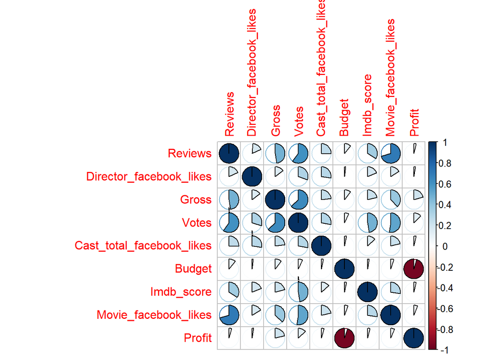

```r
corrplot(cr, method = "pie")
```

Task 2 of 2: Association Rule mining

Importing Libraries

```r
library(arules)
```

```r
library(arulesViz)
```

Reading data

```r
tdata = read.csv("Titanic.csv")#load data
glimpse(tdata)#data has 5 columns and 2201 rows
```

```
## Rows: 2,201
## Columns: 5
## $ X        <int> 1, 2, 3, 4, 5, 6, 7, 8, 9, 10, 11, 12, 13, 14, 15, 16, 17,...
## $ Class    <chr> "3rd", "3rd", "3rd", "3rd", "3rd", "3rd", "3rd", "3rd", "3...
## $ Sex      <chr> "Male", "Male", "Male", "Male", "Male", "Male", "Male", "M...
## $ Age      <chr> "Child", "Child", "Child", "Child", "Child", "Child", "Chi...
## $ Survived <chr> "No", "No", "No", "No", "No", "No", "No", "No", "No", "No"...
```

```r
class(tdata)
```

```
## [1] "data.frame"
```

```r
head(tdata)
```

```
##   X Class  Sex   Age Survived
## 1 1   3rd Male Child       No
## 2 2   3rd Male Child       No
## 3 3   3rd Male Child       No
## 4 4   3rd Male Child       No
## 5 5   3rd Male Child       No
## 6 6   3rd Male Child       No
```

Calculating missing values

```r
missing_titanic <- sum(is.na(tdata))
missing_titanic# No missing values in Titanic dataset
```

```
## [1] 0
```

No imputation is needed as we have to perform association rule mining which doesn’t need numeric values.

Sub setting data to eliminate the first index column

```r
tdata<- subset(tdata,select = -c(X))
head(tdata)
```

```
##   Class  Sex   Age Survived
## 1   3rd Male Child       No
## 2   3rd Male Child       No
## 3   3rd Male Child       No
## 4   3rd Male Child       No
## 5   3rd Male Child       No
## 6   3rd Male Child       No
```

```r
summary(tdata)
```

```
##     Class               Sex                Age              Survived
##  Length:2201        Length:2201        Length:2201        Length:2201
##  Class :character   Class :character   Class :character   Class :character
##  Mode  :character   Mode  :character   Mode  :character   Mode  :character
```

Converting to Transaction data

```r
tdata <- as (tdata, "transactions")
```

Creating the Association rules using apriori algorithm

```r
rules_Survived_Yes <- apriori(tdata, parameter = list(sup = 0.005, conf = 0.8, minlen = 2), appearance = list(default = "lhs", rhs ="Survived=Yes" ))
```

```
## Apriori
##
## Parameter specification:
##  confidence minval smax arem  aval originalSupport maxtime support minlen
##         0.8    0.1    1 none FALSE            TRUE       5   0.005      2
##  maxlen target  ext
##      10  rules TRUE
##
## Algorithmic control:
##  filter tree heap memopt load sort verbose
##     0.1 TRUE TRUE  FALSE TRUE    2    TRUE
##
## Absolute minimum support count: 11
##
## set item appearances ...[1 item(s)] done [0.00s].
## set transactions ...[10 item(s), 2201 transaction(s)] done [0.00s].
## sorting and recoding items ... [10 item(s)] done [0.00s].
## creating transaction tree ... done [0.00s].
## checking subsets of size 1 2 3 4 done [0.00s].
## writing ... [8 rule(s)] done [0.00s].
## creating S4 object  ... done [0.00s].
```

```r
summary(rules_Survived_Yes)
```

```
## set of 8 rules
##
## rule length distribution (lhs + rhs):sizes
## 3 4
## 4 4
##
##    Min. 1st Qu.  Median    Mean 3rd Qu.    Max.
##     3.0     3.0     3.5     3.5     4.0     4.0
##
## summary of quality measures:
##     support           confidence        coverage             lift
##  Min.   :0.005906   Min.   :0.8602   Min.   :0.005906   Min.   :2.663
##  1st Qu.:0.009087   1st Qu.:0.8696   1st Qu.:0.010450   1st Qu.:2.692
##  Median :0.023626   Median :0.9248   Median :0.026579   Median :2.863
##  Mean   :0.030157   Mean   :0.9277   Mean   :0.032428   Mean   :2.872
##  3rd Qu.:0.047592   3rd Qu.:0.9793   3rd Qu.:0.052476   3rd Qu.:3.032
##  Max.   :0.064062   Max.   :1.0000   Max.   :0.065879   Max.   :3.096
##      count
##  Min.   : 13.00
##  1st Qu.: 20.00
##  Median : 52.00
##  Mean   : 66.38
##  3rd Qu.:104.75
##  Max.   :141.00
##
## mining info:
##   data ntransactions support confidence
##  tdata          2201   0.005        0.8
```

Inspecting the top 3 pairs by Lift

```r
inspect(head(sort(rules_Survived_Yes, by="lift"),3))
```

```
##     lhs                                 rhs            support     confidence
## [1] {Class=2nd,Age=Child}            => {Survived=Yes} 0.010904134 1.0000000
## [2] {Class=2nd,Sex=Female,Age=Child} => {Survived=Yes} 0.005906406 1.0000000
## [3] {Class=1st,Sex=Female}           => {Survived=Yes} 0.064061790 0.9724138
##     coverage    lift     count
## [1] 0.010904134 3.095640  24
## [2] 0.005906406 3.095640  13
## [3] 0.065879146 3.010243 141
```

The three pairs of entries have the highest lift value.

Plotting the top 3 pairs by Lift

```r
datadd <- head(sort(rules_Survived_Yes, by="lift"),n = 3)
head(quality(datadd))
```

```
##       support confidence    coverage     lift count
## 1 0.010904134  1.0000000 0.010904134 3.095640    24
## 5 0.005906406  1.0000000 0.005906406 3.095640    13
## 3 0.064061790  0.9724138 0.065879146 3.010243   141
```

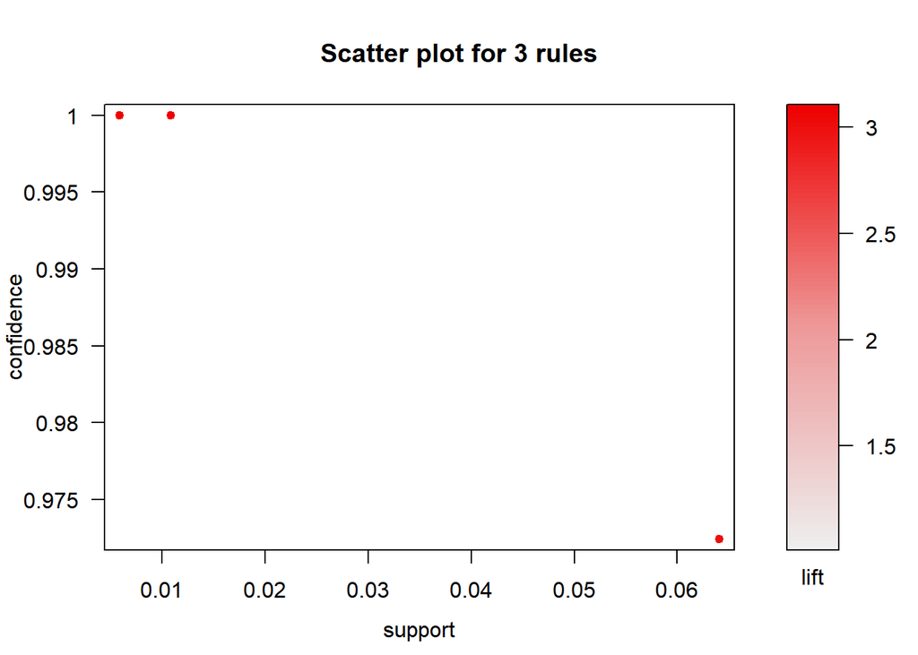

```r
plot(datadd)
```

```r
plot(datadd , method = "graph", engine = "htmlwidget")
```

[interactive chart not shown]